# Mercury_incidents_tfidfandwordvec-clustering1.0

```python
import pandas as pd
import numpy as np
from bs4 import BeautifulSoup
import re
import nltk
from nltk.corpus import stopwords
from sklearn.feature_extraction.text import CountVectorizer
from sklearn.feature_extraction.text import TfidfVectorizer
from sklearn.cluster import KMeans
from sklearn.decomposition import PCA
from sklearn.decomposition import TruncatedSVD
from sklearn.ensemble import RandomForestClassifier
from sklearn.linear_model.logistic import LogisticRegression
from sklearn.linear_model import LinearRegression
from sklearn.neighbors import KNeighborsClassifier
from sklearn import metrics
from sklearn.naive_bayes import MultinomialNB
from nltk.stem import WordNetLemmatizer
from sklearn.preprocessing import Normalizer
from sklearn.preprocessing import StandardScaler
import nltk
from nltk import bigrams
from nltk import trigrams
```

```python
import gensim
from gensim import utils
import numpy as np
import sys
from sklearn.datasets import fetch_20newsgroups
from nltk import word_tokenize
from nltk import download
from nltk.corpus import stopwords
import matplotlib.pyplot as plt
from sklearn.decomposition import PCA
get_ipython().magic('matplotlib inline')
```

```python
mercury_incidents = pd.read_excel(r'C:\Madhan\Analytics\Machine_Learning_project_work\AI_ML\IT_transition_mercury\TopicModelling\Mercury Incident List.xlsx',sheet_name='Page 1')
```

```python
mercury_incidents.head(2)
```

|  | Number | Requester | Short Description | Impacted Business Service | Impacted Service Offering | Impacted application | Impacted Device / Item | Status | Assignment Group | Assigned To | ... | Number of Users Impacted? | Priority | Updated | Created | Created by | Category | Description | Environment | Requestor Country | Resolution category |
| --- | --- | --- | --- | --- | --- | --- | --- | --- | --- | --- | --- | --- | --- | --- | --- | --- | --- | --- | --- | --- | --- |
| 0 | INC9837053 | Blaire Hodgins | Grey bar blocking view of C4C opp record | Mercury Program | Mercury/Campaign to Engage | My Opportunities & Contacts Mercury | NaN | Closed | Vendor AMS Mercury CRM | Radhakrishna Yerrabothu | ... | 1 | P2S1 | 2018-11-25 11:00:41 | 2018-11-12 16:27:13 | CA014003286 | Defect/Failure | When opening the C4C opp record, a large grey ... | Production | Canada | NaN |
| 1 | INC9816510 | Siraj Aboosally | Access/ Incorrect status issue - EAT tool | Mercury Program | Mercury/System | Manage My Access Mercury | NaN | Closed | Vendor AMS Mercury SharePoint DUET | Abhishek Verma | ... | 1 | P2S1 | 2018-11-17 10:00:38 | 2018-11-09 14:48:13 | CA014003174 | Defect/Failure | Access/ Incorrect status issue - EAT tool. See... | Production | Canada | Software – Code |

2 rows × 21 columns

```python
mercury_incidents.columns
```

```
Index(['Number', 'Requester', 'Short Description', 'Impacted Business Service',
       'Impacted Service Offering', 'Impacted application',
       'Impacted Device / Item', 'Status', 'Assignment Group', 'Assigned To',
       'Outage Type', 'Number of Users Impacted?', 'Priority', 'Updated',
       'Created', 'Created by', 'Category', 'Description', 'Environment',
       'Requestor Country', 'Resolution category'],
      dtype='object')
```

```python
mercury_incidents.columns = [c.replace(' ','_') for c in mercury_incidents.columns]
```

```python
mercury_incidents.columns
```

```
Index(['Number', 'Requester', 'Short_Description', 'Impacted_Business_Service',
       'Impacted_Service_Offering', 'Impacted_application',
       'Impacted_Device_/_Item', 'Status', 'Assignment_Group', 'Assigned_To',
       'Outage_Type', 'Number_of_Users_Impacted?', 'Priority', 'Updated',
       'Created', 'Created_by', 'Category', 'Description', 'Environment',
       'Requestor_Country', 'Resolution_category'],
      dtype='object')
```

```python
mercury_incidents.Impacted_application.value_counts().head(10)
```

```
Billing Mercury                        880
My Engagements Maint Mercury           869
My Opportunities & Contacts Mercury    861
SAP GUI Mercury                        822
My Travel & Expense Mercury            743
Account Maint Mercury                  576
My timesheet – Grid (Mercury)          533
Program Mercury                        472
Manage My Access Mercury               335
EY/Mercury                             281
Name: Impacted_application, dtype: int64
```

```python
travel_exp  = mercury_incidents[mercury_incidents.Impacted_application=='My Travel & Expense Mercury']
```

```python
travel_exp.shape
```

```
(743, 21)
```

```python
billing_mercury_words = ['urgent','gfis','mercury','billing','-',':','dear','pls','in01','issue','sap','chase','ticket','duplicate','incident',
                   'fdr','iii','III','bau','fup','fw','hypercare','<','>','my','T&E','t&e','pe1','global','gsa','sap','ca','de','name','engagement','maintenance','maint','please','hello',
                         'user','via','germany','vfx','bta','gsg','friday','july','made','try','ireland','new','getting','get',
                        'begin','hi','tthe','the']
```

```python
engagement_maint_words = ['urgent','gfis','mercury','billing','-',':','dear','pls','in01','issue','sap','chase','ticket','duplicate','incident',
                   'fdr','iii','III','bau','fup','fw','hypercare','<','>','my','T&E','t&e','pe1','global','gsa','sap','ca','de','name','engagement','engagements','maintenance','maint','please','hello',
                         'user','via','germany','vfx','bta','gsg','friday','july','made','try','ireland','new','getting','get',
                        'begin','hi','tthe','the']
```

```python
opportunities_contacts_words = ['opportunity','contact','urgent','gfis','mercury','billing','-',':','dear','pls','in01','issue','sap','chase','ticket','duplicate','incident',
                                'fdr','iii','III','bau','fup','fw','hypercare','<','>','my','T&E','t&e','pe1','global','gsa','sap','ca','de','name','engagement','engagements','maintenance','maint','please','hello',
                                 'user','via','germany','vfx','bta','gsg','friday','july','made','try','ireland','new','getting','get',
                                    'begin','hi','tthe','the','opportunities','contact','contacts']
```

```python
sap_gui = ['opportunity','contact','urgent','gfis','gui','mercury','billing','-',':','dear','pls','in01','issue','sap','chase','ticket','duplicate','incident',
                                'fdr','iii','III','bau','fup','fw','hypercare','<','>','my','T&E','t&e','pe1','global','gsa','sap','ca','de','name','engagement','engagements','maintenance','maint','please','hello',
                                 'user','via','germany','vfx','bta','gsg','friday','july','made','try','ireland','new','getting','get',
                                    'begin','hi','tthe','the','opportunities','contact','contacts']
```

```python
tra_exp = ['travel','expense','opportunity','contact','urgent','gfis','gui','mercury','billing','-',':','dear','pls','in01','issue','sap','chase','ticket','duplicate','incident',
                                'fdr','iii','III','bau','fup','fw','hypercare','<','>','my','T&E','t&e','pe1','global','gsa','sap','ca','de','name','engagement','engagements','maintenance','maint','please','hello',
                                 'user','via','germany','vfx','bta','gsg','friday','july','made','try','ireland','new','getting','get',
                                    'begin','hi','tthe','the','opportunities','contact','contacts']
```

```python
SD = travel_exp.Short_Description
```

```python
default_stopwords = set(nltk.corpus.stopwords.words('english'))
```

```python
words = nltk.word_tokenize(str(SD))
```

```python
words = [w.lower() for w in words if len(w)>2]
```

```python
words = [w for w in words if not w.isnumeric()]
```

```python
words = [w for w in words if not w in default_stopwords and w not in opportunities_contacts_words]
```

```python
words
```

```
['travel',
 'expense',
 'error',
 'property',
 "'day",
 '...',
 'travel',
 'expense',
 '...',
 'travel',
 'expenses',
 'error',
 '...',
 'travel',
 'expense',
 'expenses',
 'module',
 'error',
 'travel',
 'expense',
 '...',
 'expense',
 'report',
 'belgium',
 'per',
 'diems',
 'travel',
 'expense',
 'company',
 'car',
 '...',
 'travel',
 'expense',
 'timesheet',
 '...',
 'travel',
 'expense',
 'ths',
 '...',
 'travel',
```

[output cut: 201 more lines]

```
 '...',
 'seeing',
 'reimbursed',
 'expenses',
 'rep',
 '...',
 'date',
 'format',
 'travel',
 'expense',
 '...',
 'short_description',
 'length',
 'dtype',
 'object']
```

# UNIGRAM

tokens = str(corpus)

# tokens_words = nltk.word_tokenize(tokens)

unigram = nltk.FreqDist(words) unigram = pd.DataFrame([unigram],columns=unigram.keys()) unigram = unigram.transpose()

# BIGRAM

tokens_1 = [token.lower() for token in words if len(token) > 3] #same as unigrams bi_tokens = bigrams(tokens_1) tri_tokens = trigrams(tokens_1) bi_tokens = list(bi_tokens) bi_token_count = [(item, bi_tokens.count(item)) for item in sorted(set(bi_tokens))] bi_token_count = pd.DataFrame(bi_token_count) bi_token_count = bi_token_count.rename(columns={0:'trigrams',1:'counts'}) sorted_counts_bi = bi_token_count.sort_values(['counts'],ascending=False)

# bi_token_count.to_csv('Ground_bi_Not_OK_token.csv')

# TRIGRAM

tri_tokens = list(tri_tokens) tri_token_count = [(item, tri_tokens.count(item)) for item in sorted(set(tri_tokens))] tri_token_count = pd.DataFrame(tri_token_count)

# tri_token_count.to_csv('Ground_tri_Not_OK_token.csv')

tri_token_count = pd.DataFrame(tri_token_count) tri_token_count = tri_token_count.rename(columns={0:'trigrams',1:'counts'}) sorted_counts_tri = tri_token_count.sort_values(['counts'], ascending=False)

```python
#for word, frequency in fdist.most_common(50):
 #   print(u'{};{}'.format(word, frequency))
```

```python
def review_to_words( SD ):
    lm = WordNetLemmatizer()
    letters_only = re.sub("[^a-zA-Z]", " ", SD)
    sentences = nltk.word_tokenize(str(letters_only))
    sentences = [word.lower() for word in sentences]
    lem_word = [lm.lemmatize(word) for word in sentences if not word in default_stopwords and
                word not in tra_exp]
    #tags = st.tag(lem_word)
    #tagged_words = [word for word,tag in tags if tag!='PERSON' and tag!='LOCATION']
    tokens = [word.lower() for word in lem_word if len(word) > 2]
    print(tokens)
    return( " ".join(tokens))
```

```python
SD.iloc[5]
```

```
'Mercury -  <My Travel & Expense Mercury> - <Error,: Error: Pers.no.xxxxxxx is blocked by user xxxxxxx>'
```

```python
print("Number of Rows Parsed......................\n")
corpus = []
num_SD = len(SD)
%time
for i in range( 0, num_SD ):
    # If the index is evenly divisible by 1000, print a message
    if( (i+1)%250 == 0 ):
        print("Cleaned Short Descriptions %d of %d" % ( i+1, num_SD ))
    corpus.append( review_to_words(str(SD.iloc[i])))
```

```
Number of Rows Parsed......................

Wall time: 0 ns
['error', 'property', 'day', 'found', 'type', 'travelsummary']
['unable', 'edit']
['expense', 'error', 'page', 'displayed']
['expense', 'module']
['error']
['error', 'error', 'pers', 'xxxxxxx', 'blocked', 'xxxxxxx']
['report', 'belgium', 'per', 'diems']
['company', 'car', 'error', 'required', 'data', 'maintained', 'custom', 'table']
['timesheet', 'mobile', 'page', 'displayed']
['page', 'displayed']
['error']
['unable', 'search']
['error', 'page', 'displayed']
['engage', 'invoice', 'page', 'displayed']
[]
['error', 'page', 'displayed', 'timesheet', 'list', 'mobile']
['error', 'page', 'displayed']
['one', 'gate', 'application', 'working', 'environment']
['property', 'tue', 'found', 'typ', 'summary']
['property', 'mon', 'found', 'type', 'travelsummary', 'error']
['data', 'returned']
['rfc', 'error', 'exception', 'condition', 'infotype', 'found', 'triggered']
['property', 'mon', 'found', 'type', 'travelsummary']
['service', 'deleg', 'failed', 'system', 'administrator']
[]
['error', 'service', 'deleg', 'failed', 'system', 'administrator']
['cost', 'assignment', 'contains', 'error']
['error', 'property', 'day', 'found', 'type', 'travelsummary']
['test']
['test']
['property', 'sun', 'found', 'type', 'travelsummary']
['error', 'xxxxxxxx', 'blocked', 'time', 'booking', 'change', 'recorded', 'time', 'allowed']
['trouble', 'certificate']
['property', 'day', 'found', 'type', 'travelsummary']
['propery', 'sun', 'found', 'type', 'travelsummary']
['property', 'sun', 'found', 'type', 'travelsummary']
['propery', 'sun', 'found', 'type', 'travelsummary']
```

[output cut: 693 more lines]

```
['expense', 'turn', 'status', 'reimbursed']
['show', 'report', 'reimbursed']
['duplicating', 'line', 'changing', 'date', 'cause', 'issue', 'description']
['page', 'displayed']
['per', 'attached', 'jennifer', 'yang', 'trip', 'top', 'right', 'area', 'pay', 'employee', 'pay', 'amex', 'total', 'pay', 'employee', 'tota']
['status', 'reimbursed', 'approved', 'displayed']
['status', 'report', 'appearing']
['internal', 'error']
['expense', 'work']
['add', 'attachment', 'possible']
['unable', 'edit', 'modify', 'record']
['page', 'displayed']
['information', 'regarding', 'claim', 'reimbursement']
['seeing', 'reimbursed', 'expense', 'report', 'showing', 'submitted', 'title']
['date', 'format', 'changed', 'back', 'prior']
```

```python
corpus
```

```
['error property day found type travelsummary',
 'unable edit',
 'expense error page displayed',
 'expense module',
 'error',
 'error error pers xxxxxxx blocked xxxxxxx',
 'report belgium per diems',
 'company car error required data maintained custom table',
 'timesheet mobile page displayed',
 'page displayed',
 'error',
 'unable search',
 'error page displayed',
 'engage invoice page displayed',
 '',
 'error page displayed timesheet list mobile',
 'error page displayed',
 'one gate application working environment',
 'property tue found typ summary',
 'property mon found type travelsummary error',
 'data returned',
 'rfc error exception condition infotype found triggered',
 'property mon found type travelsummary',
 'service deleg failed system administrator',
 '',
 'error service deleg failed system administrator',
 'cost assignment contains error',
 'error property day found type travelsummary',
 'test',
 'test',
 'property sun found type travelsummary',
 'error xxxxxxxx blocked time booking change recorded time allowed',
 'trouble certificate',
 'property day found type travelsummary',
 'propery sun found type travelsummary',
 'property sun found type travelsummary',
 'propery sun found type travelsummary',
 'mst ecc eat cmparison report amount mismatch eat ecc country specific report',
 'unable file reimbursement',
 'expense error pers xxxxxxx blocked xxxxxxx',
```

[output cut: 688 more lines]

```
 'expense turn status reimbursed',
 'show report reimbursed',
 'duplicating line changing date cause issue description',
 'page displayed',
 'per attached jennifer yang trip top right area pay employee pay amex total pay employee tota',
 'status reimbursed approved displayed',
 'status report appearing',
 'internal error',
 'expense work',
 'add attachment possible',
 'unable edit modify record',
 'page displayed',
 'information regarding claim reimbursement',
 'seeing reimbursed expense report showing submitted title',
 'date format changed back prior']
```

## TfIDFVectorizer

```python
tfidf = TfidfVectorizer(stop_words='english',ngram_range=(1,3),min_df=50,max_features=5000)
```

```python
X_ok_dtm = tfidf.fit_transform(corpus)
```

```python
X_ok_dtm.shape
```

```
(743, 26)
```

```python
terms = tfidf.get_feature_names()
```

```python
terms
```

```
['day',
 'day type',
 'day type travelsummary',
 'displayed',
 'error',
 'error property',
 'expense',
 'exprep',
 'exprep srv',
 'exprep srv failed',
 'failed',
 'page',
 'property',
 'property day',
 'property day type',
 'report',
 'service',
 'service exprep',
 'service exprep srv',
 'srv',
 'srv failed',
 'travelsummary',
 'trip',
 'type',
 'type travelsummary',
 'unable']
```

```python
from sklearn.feature_extraction.text import TfidfVectorizer
import numpy as np

#lectures = ["this is some food", "this is some drink"]
#vectorizer = TfidfVectorizer()
#X = vectorizer.fit_transform(lectures)
indices = np.argsort(tfidf.idf_)[::-1]
features = tfidf.get_feature_names()
top_n = 10
top_features = [features[i] for i in indices[:top_n]]
print(top_features)
```

```
['day type travelsummary', 'property day type', 'day type', 'displayed', 'property day', 'day', 'error property', 'page', 'trip', 'unable']
```

```python
counts =  tfidf.vocabulary_
```

## SVD for Dimension Reduction

```python
svd = TruncatedSVD(n_components=6)
```

```python
tfidfnew = svd.fit(X_ok_dtm)
```

```python
var = tfidfnew.explained_variance_ratio_
```

```python
sortedvar = np.sort(var)[::-1]
```

```python
sortedvar.cumsum()
```

```
array([0.14904122, 0.2871876 , 0.41283469, 0.52827574, 0.640681  ,
       0.73281023])
```

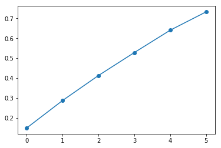

```python
plt.plot(sortedvar.cumsum(),marker='o')
```

```python
X_ok_dtm_new = tfidfnew.fit_transform(X_ok_dtm)
```

```python
X_ok_dtm_new.shape
```

```
(743, 6)
```

## K_MEANS CLUSTERNING

```python
from sklearn.cluster import KMeans

num_clusters = 7

km = KMeans(n_clusters=num_clusters)

%time km.fit(X_ok_dtm_new)

clusters = km.labels_.tolist()
```

```
Wall time: 53 ms
```

```python
#km.predict()
```

```python
len(clusters)
```

```
743
```

```python
order_centroids = km.cluster_centers_.argsort()[:,::-1]
```

```python
order_centroids.shape
```

```
(7, 6)
```

```python
clusters_num = pd.DataFrame(clusters,columns={'clusters_num'})
```

```python
#clusters_num.to_csv('billing_mercury_clusters.csv')
```

```python
cluster_range = range( 1, 15 )
cluster_errors = []

for num_clusters in cluster_range:
    clusters = KMeans( num_clusters )
    clusters.fit( X_ok_dtm_new )
    cluster_errors.append( clusters.inertia_ )
```

```python
clusters_df = pd.DataFrame( { "num_clusters":cluster_range, "cluster_errors": cluster_errors } )
```

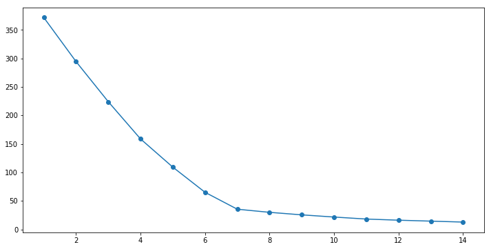

```python
import numpy as np
import matplotlib.pyplot as plt
import matplotlib.cm as cm
import seaborn as sn
%matplotlib inline
plt.figure(figsize=((12,6)))
plt.plot(clusters_df.num_clusters, clusters_df.cluster_errors,marker='o')
```

```python
cluster_errors
```

```
[371.76694004529287,
 294.4486942947732,
 224.00580733811586,
 158.69387768739767,
 109.24004715823983,
 65.04552800269596,
 35.380387254870655,
 29.895573479091013,
 25.460843599642395,
 21.625294679394468,
 18.109016060402734,
 16.1020784910005,
 14.454511014703407,
 12.778342606790769]
```

```python
corpus_df = pd.DataFrame(corpus,columns={'sd'})
```

```python
cluster_wise = pd.concat([corpus_df,clusters_num],axis=1)
```

```python
cluster_wise.to_csv('new.csv')
```

```python
from sklearn.metrics import silhouette_score
```

```python
silhouette_score(X_ok_dtm_new, clusters_num, sample_size=1000)
```

```
0.7162839857538531
```

### Word2Vec based clustering

from gensim.models import Word2Vec

from nltk.cluster import KMeansClusterer import nltk

from sklearn import cluster from sklearn import metrics

# training data

sentences = [['this', 'is', 'the', 'good', 'machine', 'learning', 'book'], ['this', 'is', 'another', 'book'], ['one', 'more', 'book'], ['this', 'is', 'the', 'new', 'post'], ['this', 'is', 'about', 'machine', 'learning', 'post'],  
['and', 'this', 'is', 'the', 'last', 'post']]

# training model

model = Word2Vec(sentences, min_count=1)

# get vector data

X = model[model.vocab] print (X)

print (model.similarity('this', 'is'))

print (model.similarity('post', 'book'))

print (model.most_similar(positive=['machine'], negative=[], topn=2))

print (model['the'])

print (list(model.vocab))

print (len(list(model.vocab)))

NUM_CLUSTERS=3 kclusterer = KMeansClusterer(NUM_CLUSTERS, distance=nltk.cluster.util.cosine_distance, repeats=25) assigned_clusters = kclusterer.cluster(X, assign_clusters=True) print (assigned_clusters)

words = list(model.vocab) for i, word in enumerate(words):  
print (word + ":" + str(assigned_clusters[i]))

kmeans = cluster.KMeans(n_clusters=NUM_CLUSTERS) kmeans.fit(X)

print ("Cluster id labels for inputted data") print (labels) print ("Centroids data") print (centroids)

print ("Score (Opposite of the value of X on the K-means objective which is Sum of distances of samples to their closest cluster center):") print (kmeans.score(X))

silhouette_score = metrics.silhouette_score(X, labels, metric='euclidean')

print ("Silhouette_score: ") print (silhouette_score)

```python
from gensim.models import Word2Vec

from nltk.cluster import KMeansClusterer
import nltk
from sklearn import cluster
from sklearn import metrics
```

```python
sentences = []
for c in corpus:
    words = nltk.word_tokenize(c)
    sentences.append(words)
```

```python
len(sentences)
```

[output not shown]

```python
model = Word2Vec(sentences, min_count=1,workers=4,size=100,window=5,iter=10)
```

```python
model.wv.syn0.shape
```

```
(885, 100)
```

```python
model.wv.vocab
```

[output not shown]

[output cut: 830 more lines]

```
 'additional': <gensim.models.keyedvectors.Vocab at 0x267bba61f60>,
 'rate': <gensim.models.keyedvectors.Vocab at 0x267bba61f98>,
 'card': <gensim.models.keyedvectors.Vocab at 0x267bba61fd0>,
 'pulling': <gensim.models.keyedvectors.Vocab at 0x267bba64048>,
 'write': <gensim.models.keyedvectors.Vocab at 0x267bba64080>,
 'gema': <gensim.models.keyedvectors.Vocab at 0x267bba640b8>,
 'submission': <gensim.models.keyedvectors.Vocab at 0x267bba640f0>,
 'reported': <gensim.models.keyedvectors.Vocab at 0x267bba64128>,
 'passed': <gensim.models.keyedvectors.Vocab at 0x267bba64160>,
 'ernst': <gensim.models.keyedvectors.Vocab at 0x267bba64198>,
 'young': <gensim.models.keyedvectors.Vocab at 0x267bba641d0>,
 'ravensburg': <gensim.models.keyedvectors.Vocab at 0x267bba64208>,
 'responce': <gensim.models.keyedvectors.Vocab at 0x267bba64240>,
 'february': <gensim.models.keyedvectors.Vocab at 0x267bba64278>,
 'today': <gensim.models.keyedvectors.Vocab at 0x267bba642b0>}
```

```python
word_vectors = model.wv.syn0
n_words = word_vectors.shape[0]
vec_size = word_vectors.shape[1]
```

```python
print(n_words)
print(vec_size)
```

```
885
100
```

```python
 print("#words = {0}, vector size = {1}".format(n_words, vec_size))
```

```
#words = 885, vector size = 100
```

```python
# get vector data
X = model[model.wv.vocab]
print (X.shape)
```

```
(885, 100)
```

```python
X
```

```
array([[-3.24542460e-04,  1.52335921e-03,  3.37993610e-03, ...,
         5.08820778e-03, -4.04213415e-03,  1.65853801e-03],
       [-4.03461466e-03, -1.88614754e-03, -2.88080052e-03, ...,
        -3.98543291e-03, -1.15706958e-03, -2.05783872e-03],
       [ 1.00622805e-04,  1.28328812e-03, -9.03336186e-05, ...,
        -3.59648117e-03,  3.29354522e-03, -1.72626824e-05],
       ...,
       [ 4.09937184e-03,  4.45826119e-03,  1.36930612e-03, ...,
        -2.51958985e-03, -1.55083882e-03,  2.35670689e-03],
       [-8.05121846e-04, -3.56247113e-03,  4.25655674e-03, ...,
        -6.45229302e-04,  1.94643624e-03, -3.71824531e-03],
       [-3.97869200e-03, -2.56582932e-03, -1.01538817e-03, ...,
        -8.32921010e-04, -3.84589680e-03,  5.57518448e-04]], dtype=float32)
```

```python
#print (model.wv.similar_by_word('this', 'is'))
#print (model.wv.similarity('post', 'book'))

print (model.most_similar(positive=['invoice'], negative=[], topn=10))

#print (model['the'])

#print (list(model.vocab))
#print (len(list(model.vocab)))
```

[output not shown]

# W2V WITH K MEANS 3RD APPROAOCH

```python
model.save('word2vec')
```

```python
model = gensim.models.KeyedVectors.load('word2vec')
```

```python
def average_word_vectors(words, model, vocabulary, num_features):

    feature_vector = np.zeros((num_features,),dtype="float64")
    nwords = 0.

    for word in words:
        if word in vocabulary:
            nwords = nwords + 1.
            feature_vector = np.add(feature_vector, model[word])

    if nwords:
        feature_vector = np.divide(feature_vector, nwords)

    return feature_vector
```

```python
def averaged_word_vectorizer(corpus, model, num_features):
    vocabulary = set(model.wv.index2word)
    features = [average_word_vectors(tokenized_sentence, model, vocabulary, num_features)
                    for tokenized_sentence in corpus]
    return np.array(features)
```

```python
# get document level embeddings
w2v_feature_array = averaged_word_vectorizer(corpus=sentences, model=model,
                                             num_features=100)
pd.DataFrame(w2v_feature_array)
```

[output not shown]

861 rows × 100 columns

```python
from sklearn.cluster import AffinityPropagation

ap = AffinityPropagation()
ap.fit(w2v_feature_array)
cluster_labels = ap.labels_
cluster_labels = pd.DataFrame(cluster_labels, columns=['ClusterLabel'])
#pd.concat([corpus_df, cluster_labels], axis=1)
```

```python
cluster_labels.shape
```

[output not shown]

```python
kmeans = cluster.KMeans(n_clusters=6)
#kmeans.fit(X)
kmeans.fit(w2v_feature_array)

labels = kmeans.labels_
centroids = kmeans.cluster_centers_

print ("Cluster id labels for inputted data")
print (labels.size)
print ("Centroids data")
print (centroids.size)

print ("Score (Opposite of the value of X on the K-means objective which is Sum of distances of samples to their closest cluster center):")
print (kmeans.score(w2v_feature_array))

silhouette_score = metrics.silhouette_score(w2v_feature_array, labels, metric='euclidean')

print ("Silhouette_score: ")
print (silhouette_score)
```

[output not shown]

```python
cluster_range = range( 1, 10 )
cluster_errors = []

for num_clusters in cluster_range:
    kmeans = KMeans( num_clusters )
    kmeans.fit(w2v_feature_array)
    cluster_errors.append( kmeans.inertia_ )
```

```python
clusters_df = pd.DataFrame( { "num_clusters":cluster_range, "cluster_errors": cluster_errors } )
```

```python
cluster_errors
```

```
[0.31184189088149533,
 0.27517950188125684,
 0.263451795052003,
 0.2552206406576656,
 0.2479774283884787,
 0.24080228457091263,
 0.23657129022633838,
 0.23235104461466413,
 0.22415768783104534]
```

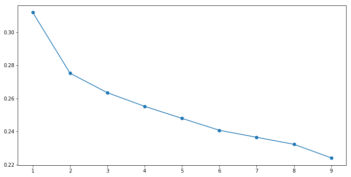

```python
import numpy as np
import matplotlib.pyplot as plt
import matplotlib.cm as cm
import seaborn as sn
%matplotlib inline
plt.figure(figsize=((12,6)))
plt.plot(clusters_df.num_clusters, clusters_df.cluster_errors,marker='o')
```

```python
labels = pd.DataFrame(labels,columns={'w2vclusternum'})
```

```python
w2vcluster_wise = pd.concat([corpus_df,labels],axis=1)
```

```python
w2vcluster_wise.to_csv('w2vcluster.csv')
```